Agrupamentos dos Estabelecimentos de Internação registrados no TABNET, São Paulo, biênio 2020/2021, de acordo com a evolução da Covid19 Síndrome Respiratória Aguda Grave **Prevent Senior** *Sistema de Gestão da Qualidade* Última atualização em 07 / 10 / 2022 às 15:40 horas.

Abstract

Este relatório agrupa os estabelecimentos de internação para covid-19 (Síndrome Respiratória Aguda Grave) registrados no TABNET, Secretaria Municipal de Saúde de São Paulo, em grupos homogêneos em função do grau de similaridade entre si, a partir das variáveis **total de internação**, **cura**, **óbito** e **taxa de óbito** (evolução dos pacientes internados).

# Introdução

Este relatório tem por objetivo agrupar os estabelecimentos de internação registrados na Secretaria Municipal de Sáude de São Paulo em relação à evolução dos pacientes no que diz respeito à Covid-19 com diagnóstico de Síndrome Respiratória Aguda Grave (SRAG), nos anos de 2020 e 2021.

A ideia principal é agrupar os objetos (estabelecimentos de internação) com base nas características das variáveis (evolução dos pacientes internados em suas dependências).

O agrupamento destes estabelecimentos de internação com estas variáveis (*features*) foi processado pela técnica de interdependência **análise de clusters**.

# Análise de *clusters*

A análise de *clusters* agrupa os objetos (estabelecimentos de internação) com base em suas próprias características (evolução dos pacientes internados), buscando uma estrutura natural para estes objetos.

O objetivo da técnica é segmentar as observações em grupos homogêneos internamente (estabelecimentos de internação com medidas de evolução) e heterogêneos entre si e mutuamente exclusivos.

Esta análise identifica objetos semelhantes (estabelecimentos de internação) com base em suas semelhanças (*features*). Ou seja, a técnica identifica grupos de objetos (estabelecimentos de internação) de modo que cada objeto se assemelha aos demais do agrupamento.

Na análise de *clusters*, diferentemente de outras técnicas de análises multivariadas, as *features* de agrupamento (variáveis estatísticas) são selecionadas pelo pesquisador (não são selecionadas empiricamente).

É uma técnica descritiva, com fortes propriedades matemáticas e que não é apropriada para realizar inferências de características da população a partir de amostras.

## Análise das variáveis e dos objetos para formar os *clusters*

A seleção das *features* deve refletir a estrutura inerente que formam os grupos. Cabe ao pesquisador selecionar aquelas que se alinham ao objetivo da pesquisa. Convém minimizar o uso de variáveis não representativas e atentar para a presença de multicolinariedade (pode interferir na ponderação das medidas de similaridade).

Esta técnica é altamente sensível à inclusão de variáveis com comportamentos atípicos (*outliers*). Convém verificar a existência de *outliers* e considerar mecanismos para minimizar seus impactos.

# Base de dados de 2020

A base de dados para esta análise está disponível no aplicativo [TABNET](https://www.prefeitura.sp.gov.br/cidade/secretarias/saude/tabnet/index.php?p=296871) desenvolvido pelo DATASUS.

A Secretaria Municipal de Sáude de São Paulo disponibiliza o [TABNET](https://www.prefeitura.sp.gov.br/cidade/secretarias/saude/tabnet/index.php?p=296871) para o acesso às bases de dados de população e dos sistemas de informações do SUS.

## Carregando a base de dados

Esta análise traz o número de casos (**contéudo**) por estabelecimento de internação (**linha**) e por evolução (**coluna**) da página [COVID 19 Síndrome Respiratória Aguda Grave (SGAG)](http://tabnet.saude.prefeitura.sp.gov.br/cgi/tabcgi.exe?secretarias/saude/TABNET/RSRAG/sragh.def).

## Visão geral dos dados

```
## Rows: 151
## Columns: 8
## $ estab_inter  <chr> "2077477 HOSP STA MARCELINA SAO PAULO", "2078015 HC DA FM~
## $ cura         <int> 2837, 2410, 1847, 1594, 1438, 1443, 1388, 1415, 1745, 136~
## $ obito        <int> 748, 1058, 545, 545, 752, 613, 611, 546, 115, 536, 51, 64~
## $ obito_outros <int> 136, 38, 2, 16, 1, 3, 1, 34, 6, 4, NA, 5, 2, 1, 3, 18, 1,~
## $ ignorado     <int> 4, 22, 2, 2, 1, 8, 1, 14, 5, 1, 11, 1, 17, 63, 1, NA, 1, ~
## $ sem_info     <int> 55, 8, 15, 71, 17, 1, 43, 11, 98, 13, 38, NA, 465, 53, NA~
## $ total        <int> 3780, 3536, 2411, 2228, 2209, 2068, 2044, 2020, 1969, 191~
## $ taxa_ob      <dbl> 0.19788360, 0.29920814, 0.22604728, 0.24461400, 0.3404255~
```

## Entendimento da base de dados

```
##   rows columns discrete_columns continuous_columns all_missing_columns
## 1  151       8                1                  7                   0
##   total_missing_values complete_rows total_observations memory_usage
## 1                  121            63               1208        23240
```

[output not shown]

## Tipos de valores e ocorrência de valores ausentes.

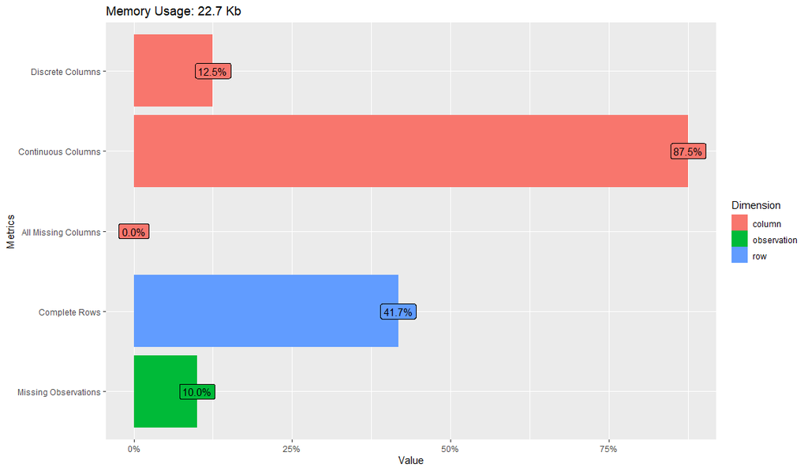

## Perfil dos valores ausentes

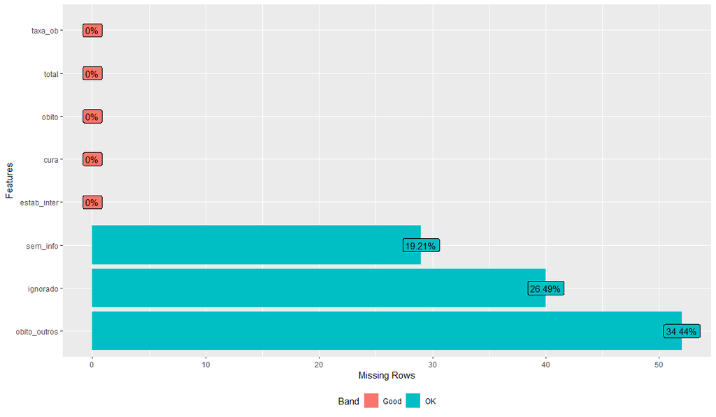

## Correlação entre as variáveis

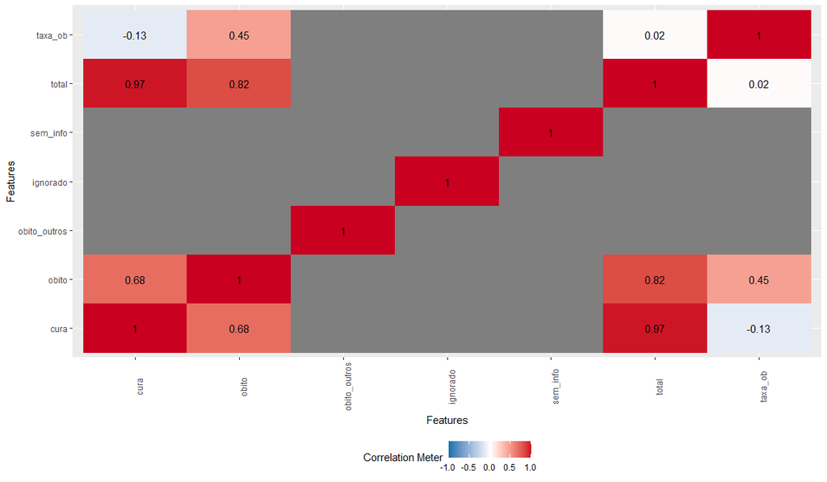

## Distribuição das variáveis quantitativas.

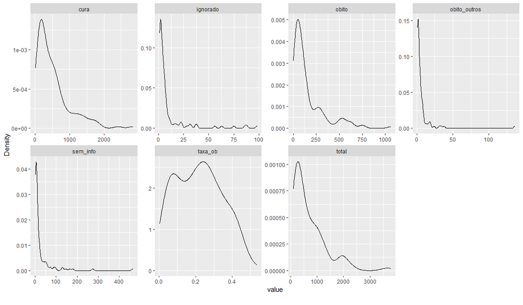

# Preparação dos dados

Para fins desta análise foram considerados todos os estabelecimentos de internação com um número de casos igual ou maior a 100 casos de internação/ano. Foram selecionados 151 estabelecimentos de internação com esta característica.

No TABNET, no objeto evolução constam cinco *features*: cura, óbito, óbito por outras causas, ignorado e sem informação. As *features* selecionadas para esta análise foram **cura**, **óbito** e **total de casos**. A variável **taxa de óbito** é a razão entre as variáveis **óbito** e **total de casos**.

As variáveis **óbito por outras causas**, **ignorado** e **sem informação** foram excluídas da análise por haver muitos *missing value* (dados ausentes).

A próxima saída ilustra os resultados dos seis primeiros estabelecimentos de internação (em ordem decrescente pelo total de casos).

```
##   cura obito total   taxa_ob
## 1 2837   748  3780 0.1978836
## 2 2410  1058  3536 0.2992081
## 3 1847   545  2411 0.2260473
## 4 1594   545  2228 0.2446140
## 5 1438   752  2209 0.3404255
## 6 1443   613  2068 0.2964217
```

## Resumo sumário das variáveis

A próxima saída trás os valores de seis medidas (em ordem crescente):

- Menor valor (*Min*): o menor valor da variável registrada em algum estabelecimento de internação.
- Primeiro quartil Q<sub>1</sub> (*1st Qu*): 25% os estabelecimentos de internação registraram um valor da variável abaixo desse valor.
- Mediana Q<sub>2</sub> (*median*): 50% os estabelecimentos de internação registraram um valor da variável abaixo desse valor.
- Média (*mean*): média aritmética dos valores da variável registrada pelos estabelecimentos de internação.
- Terceiro quartil Q<sub>3</sub> (*3rd Qu*): 75% os estabelecimentos de internação registraram um valor da variável abaixo desse valor.
- Maior valor (*Max*): o maior valor da variável registrada em algum estabelecimento de internação.

```
##       cura            obito            total           taxa_ob
##  Min.   :  11.0   Min.   :   1.0   Min.   : 100.0   Min.   :0.002755
##  1st Qu.: 153.5   1st Qu.:  41.0   1st Qu.: 251.5   1st Qu.:0.102548
##  Median : 368.0   Median :  79.0   Median : 465.0   Median :0.218274
##  Mean   : 514.2   Mean   : 155.7   Mean   : 702.5   Mean   :0.219155
##  3rd Qu.: 659.0   3rd Qu.: 191.5   3rd Qu.: 984.5   3rd Qu.:0.321535
##  Max.   :2837.0   Max.   :1058.0   Max.   :3780.0   Max.   :0.535545
```

À guisa de exemplo, considere a *feature* **taxa de óbito**:

Nos estabelecimentos de internação selecionados, se verifica que a média da taxa de óbitos por SRAG foi de 21,91% (12.8 %). Este valor é muito próximo da mediana (21,82%). Dito de outra maneira, em 2020, 50% dos estabelecimentos de internação da região metropolitana de São Paulo registraram uma taxa de óbito por SRAG de 21.82%.

Em 2020, foram registradas 109.961 casos de COVID 19 SRAG no [TABNET](http://tabnet.saude.prefeitura.sp.gov.br/cgi/tabcgi.exe?secretarias/saude/TABNET/RSRAG/sragh.def), dos quais, 24.581 casos evoluíram para óbito (taxa de óbito = 22.35%)

Observe que 25% dos estabelecimentos de internação registraram uma taxa de óbitos por SRAG igual ou maior a 32.15%.

Estas informações podem ser visualizadas no seguinte *boxplot*.

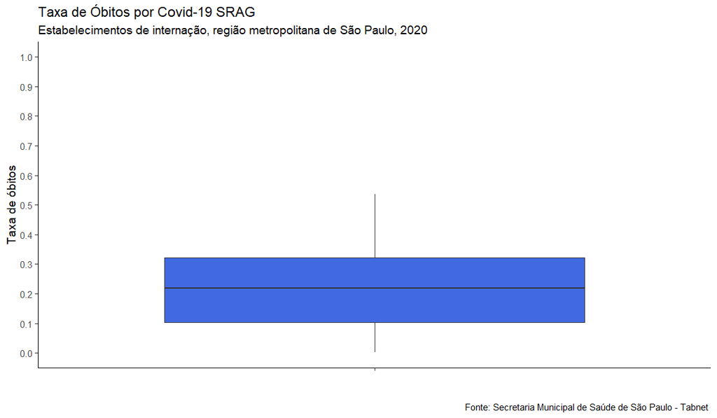

## Padronização dos dados

A utilização de variáveis com medidas e ou escalas diferentes podem distorcer a estrutura do *cluster*. Variáveis com maior dispersão têm maior peso para o cálculo das medidas de distância do que as demais.

A padronização dos dados faz com que seja atribuído o mesmo peso para cada variável. Neste estudo foi utilizada a transformação de cada variável em escore padrão (*Z score*). O método Z score padroniza cada variável de modo a apresentar uma média zero(0)e desvio padrão um (1):

$$Z = \frac{(x - média)}{desvio \ padrão}$$

```
##       cura    obito    total     taxa_ob
## 1 4.723425 3.228892 4.736602 -0.16622422
## 2 3.855131 4.918978 4.361063  0.62556721
## 3 2.710285 2.122158 2.629580  0.05385833
## 4 2.195816 2.122158 2.347926  0.19894628
## 5 1.878594 3.250699 2.318683  0.94765672
## 6 1.888761 2.492886 2.101671  0.60379250
```